Final project for CSCS530 course

# An Agent-Based Model (ABM) to Explore New Drug Target for Innate Immune Response (IIR)

Author: Yaya Zhai

Date: 04/27/2015

#### Contents

- Abstract
- Introduction
- Methods
- Code
- Results and Discussion
- Reference
- Acknowledgement

### Abstract

Innate immune response (IIR) is generally recognized as the first barrier to defend against infections. However, sometimes infections can cause serious disturbance in IIR even after the pathogens have been eliminated from the system, which includes outcomes like sepsis and systemic inflammatory response syndrome (SIRS)/ multiple organ failure (MOF). Gary An$^{[1]}$ has built an ABM to successfully predict the failure of two anti-cytokine drugs in their clinical trials. Though the predictions of all clinical experiments from the ABM accorded with the outcome of the experiment, neither of them was positive or ameliorated the sepsis situation, nor was mortality improved. Here we rebuilt the model with the ability to simulate the outcome of the system with input of different kinds of cytokine antibodies and receptor modulators, trying to find in which way to manipulate the system can ameliorate the situation, which may prove to be new drug targets.

### Introduction

Human immune system is a non-linear system to defend against infection using complex mechanisms involving multiple cells and molecules. However, the fight to eliminate pathogens can sometimes harm the normal tissues and organs as well. For example, the reactive oxygen species (ROS) that can exterminate germs can also cause death of human cells. The disturbance of infection to the immune system is very complicated and remains a threat even after the infection has been purged due to inflammatory processes. Systemic inflammatory response syndrome (SIRS)/multiple organ failure (MOF) is a life threaten after infection disturbs innate immune response (IIR)$^{[2]}$, especially in pre-ICU era. Now with the intervene of modern ICU, patients can tolerate temporally much severer organ damage and have a larger chance to survive. However, the effort of anti-cytokine drug discovery hasn’t paid off so far.

The innate immune response(IIR) is based on the behavior of cells and related inflammatory factors (cytokines). To be specific, tissue cells and different white blood cells interact with each other directly, meanwhile releasing certain chemicals including inflammatory factors (cytokines) that have distinct effects on different cells. In addition, cells can move around and have different status and actions even if they are the same type. All these together form a complicated system. By creating ABM to outline the behavior of cells and related inflammatory factors, it is possible to investigate the outcome of an interference of the system. It may give out some hints on how to ameliorate the damage caused by innate immune response. It would be very hard for other methods to model this heterogeneous and non-linear system.

In an agent-based model to describe the system behavior in SIRS/MOF$^{[1]}$, different responses corresponding the severity of initial state of infection were observed and outcomes of clinical trials for anti-cytokine treatment were successfully predicted. However, the fact that all the clinical trials were unsuccessful may suggest that better drug targets are need for SIRS/MOF. Here we rebuild the model that enabled us to explore the outcome of potential countermeasures for SIRS/MOF. This model follows An's assumptions and rules to guide the behavior of agents. To be specific, inflammation is considered to initiate and propagate at the endothelial-blood interface. Injured endothelial cells are used to represent the system damage and an arbitrary threshold was set to represent the irreversible deterioration leading to death. The core of the model is the states(injure, activate, stick, etc.) and behaviors(move, interact with other cells, produce cytokines and react to cytokines) of cells. Influence of cytokine antibodies and receptor modulators are explicitly implemented in the model to directly modify the concentrations of cytokines in space or change the concentration cells perceive. The model simulates the process and outcome of innate immune response by modeling states and actions of cells, interactions of cell-cytokines and influence of the environment(infection, antibiotic, antibodies and cytokine receptor modulators), so possible drug targets can be identified if any intervention is proven helpful.

### Methods

As stated in Introduction part, behavior of cells and molecules related to innate immune response is simulated by modeling cells as agents that can move, occupy space and have different response to environmental factors (inflammatory factors). Molecules are modeled as environmental parameters that are updated every step with regarding to specific cells that are supposed to generate or eliminate them. The oxidative stress of epithelial cells is regarded as the entire system damage, and the system is considered collapsed if total damage exceeds certain criteria. ‘antibiotic’ is a regular treatment and it is implemented by deceasing infection directly. This treatment would serve as control. Imaginary treatment including 'inflammatory factors antibody' or 'receptor modulators' serves as additional interference of the model and may directly affect the concentration of molecules (inflammatory factors antibody) or the extent to which cells detect the molecules (receptor modulators). Different interferences/treatments are performed to observe the change to the outcome (oxy status of epithelial cells) or the time till which the system is regarded as collapse.

This model concerns different kinds of cells and cytokines, and their information is shown in Table 1 and Table 2.

Table 1. Main behaviors and properties of cells.

| Cell | Mobility | state | change of states | behavior |
| --- | --- | --- | --- | --- |
| Endothelial Cells (EC) | can't move | activated, injured, dead | activated when endotoxin >=1 or its oxy <60 | produce PAF and IL-8 when activated, can be healed |
| Polymorphonuclear Leukocytes/ Neutrophils (PMN) | move | roll, stick, burst | depends on the state of corresponding EC and TNF, PAF, IL-1 | heal EC and produce cytotox when burst |
| Monocytes/ Macrophages (Monos) | move | roll, stick, activate | activated when PAF+endotoxin+INF-g -IL-10>0 | produce different cytokines; heal EC with a probability |
| anti-imflammatory T-cells(THs) | move | differentiate, activate | TH1 activates at IL-12>0, TH2 activates at IL-10>0 | activated TH1 produces INF_g and IL_12, activated TH2 produces IL-4 and IL-10 |

Table 2. Rules of change for cytokines. Endotoxin and cytotox are not cytokines, but they are listed here for convenience.

| Cytokine name | production |
| --- | --- |
| endotoxin | 10% of infection |
| cytotox | max(10,TNF) at a burst PMN cell |
| PAF | +1 at activated EC |
| IL-8 | IL-8 + TNF + IL-1 at activated EC;TNF + IL-1 at an activated Momo |
| TNF | +1 at PMN; endotoxin + PAF + TNF + INF-g at an activated Momo |
| IL-1 | +1 at PMN; endotoxin + PAF + IL-1ra at an activated Momo |
| IL-1ra | +1 at a rolling PMN when TNF and PAF > 0 |
| GCSF | (endotoxin + IL-1 + TNF + INF-g)/4 at an activated Momo |
| IL_12 | (TNF + IL-1)/2 at an activated Momo; IL_12 at activated TH1 |
| IL_10 | (TNF + IL-1)/2 at a Momo; IL-10 at activated TH2 |
| INF-g | IL-12 + TNF + IL-1 at activated TH1 |
| IL_4 | IL-10 at activated TH2 |

Generally, the systems consists of two kinds of cells. Two layers of grids of the same size were generated. One layer is occupied by stationary epithelial cells (EC) and the other immune cells including PMN, Mono and TH cells, which are put randomly in initialization. Immune cells can move within a certain distance in every time step and PMN and Mono cells has chemotaxis to PAF + endotoxin + IL-8 and PAF, respectively.

A matrix of same size with grid space would be initialized to denote the level of infection, which would decrease the 'oxy' of corresponding EC. ('oxy' is a measure of health of EC) The cytotox generated by burst PMN could decrease infection, but it would decrease 'oxy' as well because of its cell toxity.

In addition to the changes listed above, infection and the low level of EC 'oxy' can affect their neighbors, and the cytokines would diffuse in every step according to 2D-diffusion equation: $$\frac{\partial c}{\partial t} = \nu \frac{\partial ^2 c}{\partial x^2} + \nu \frac{\partial ^2 c}{\partial y^2}$$ Which can be discreted and solved for $c_{i,j}^{n+1}$ as: $$c_{i,j}^{n+1} = c_{i,j}^n + \frac{\nu \Delta t}{\Delta x^2}(c_{i+1,j}^n - 2 c_{i,j}^n + c_{i-1,j}^n) + \frac{\nu \Delta t}{\Delta y^2}(c_{i,j+1}^n-2 c_{i,j}^n + c_{i,j-1}^n)$$ where $\nu \Delta t$ is considered as diffusion rate and $\Delta x$ and $\Delta y$ are set to 1.

The interference of the system includes antibiotic, antibodies and receptor modulators. Antibiotic could directly decrease infection with a ratio, and antibodies can directly decrease corresponding cytokines with a ratio. Receptor modulators would influence the concentration of cytokines the cells perceive.

### Code

#### I.Space

Two-dimensional sequare grid would be utiliaze to generate the space for this model. Two layers of grids of the same size would be generated. One layer is occupied by stationary epithelial cells (EC) and the other immune cells including PMN, Mono and TH cells.

#### II.Agents

##### A. EC

- nonmobile agents fixed to one layer grid.
- oxy: a label to represent the health status of epithelial cells, deceasing with regard to the some inflammatory factors and infection status.
- EC_roll & EC_stick: factors governing interaction with white blood cells(PMNs and Monos).
- is_activated: activated EC would increase the value of ec-roll and ec-stick, and produce nodulators including PAF and IL-8
- is_injured: When oxy <20, EC is considered injured.
- is_dead: When oxy <=0, EC is considered dead and would not react to external stimulations.

##### B. PMN

- mobile cells moving within two grid spaces per step in normal status
- can sense inflammatory factors and move towards them (chemtoxis)
- PMN_roll: when moving activated EC with EC-roll >= 3, move slowly
- PMN_stick: PMN would stick to the EC and fix it
- PMN_burst: After a PMN is stick, it would release cytotox and heal EC; detailed implementation is in model method

##### C. Mono

- mobile cells moving within two grid spaces per step in normal status
- Mono_roll & Mono_stick: similar to PMN, but not necessarily fix EC
- is_activated: kinds of inflammatory factors produced by PMN and the probability to heal EC would change with activation state.

##### D. TH cells

- TH0 cells can differenciate into TH1 and TH2 cells
- is_activated: TH1 and TH2 cells just wander around before activation; they produce different inflammatory factors after activation

##### E. Institution

- 'infection' is regarded as the cause of immune response. It can increase by itself with time and propagate the infection to infection to neighbors.
- 'antibiotics' is added to the system after total system damage have reached certain level to directly ameliorate on the 'infection' state.
- Interventions are added to the system no earlier than the addition of antibiotics by changing the values for inflammatory factor receptors and their antibodies. When two different kinds of cells have the same kind of receptor, it is reasonable to assume receptor modulators would act on both cell types. So it is more reasonable to treat receptor modulator as a global parameter of the model class instead of model them in individual cell classes

#### III.Initial Conditions

##### A. Cells

ECs are sequentially put to one layer of the grids to fully occupy them. Other cells are randomly distributed throughout the other layer of the grid. When a place is drawn where there is already a cell occupies it, keep drawing untill an empty grid is found.

##### B. Infection

Some random grids are chosen and their corresponding infection value is set to 100.

##### C. Inflammatory factors

Concentrations of inflammatory factors are initialized as all 0.

#### IV.Model Parameters

- grid_size: the size of space
- num_PMN: number of PMN cells
- num_Mono: number of Mono cells
- num_TH0: number of TH0 cells
- num_TH1: number of TH1 cells
- num_infection: initial number of infection
- antibiotic: potency of antibiotic, which alleviate infection
- antibodies for inflammatory factors: directly decrease the concentration of inflammatory factor
- inflammatory factors receptor modulators: affect cell reaction
- arrays of infection: the extent of infection at every grid
- arrays of inflammatory factors: different concentrations of inflammatory factors at different grids for a certain time point
- total_oxy: stands for system damage (the smaller total_oxy, the larger damage)
- injured_EC: number of injured EC, the other representation of system damage

```python
%matplotlib inline

# Standard imports
import copy
import itertools
import csv

# Scientific computing imports
import numpy as np
import math
import matplotlib.pyplot as plt
import pandas
import seaborn; seaborn.set()

# Import widget methods
from IPython.html.widgets import *
```

```python
# Class of epithelial cells
class EC(object):
    def __init__(self, model, EC_id, oxy = 100, is_injured = False, is_dead = False,
                 is_activated = False, EC_roll = 0, EC_stick = 0):
        '''
        Constructor for EC class.
        By default, healthy ECs are initialtate with full oxy and empty EC_roll and EC_stick,
        not in dead, injured or activation mode.'''
        # Set model link and ID
        self.model = model
        self.EC_id = EC_id

        # Set EC parameters
        self.oxy = oxy
        self.is_injured = is_injured
        self.is_dead = is_dead
        self.is_activated = is_activated
        self.EC_roll = EC_roll
        self.EC_stick = EC_stick

    # get their own position from the model
    def get_position(self):
        return self.model.get_EC_position(self.EC_id)

    # PMN and Mono can heal EC
    def heal_EC(self):
        self.oxy = 100
        self.is_injured = False
        self.is_dead = False
        self.is_activated = False
        self.EC_roll = 0
        self.EC_stick = 0

    # set the status of dead EC cell
    def dead_EC(self):
        self.oxy = 0
        self.is_dead = True
        self.is_activated = False
        self.is_injured = True
        self.EC_roll = 0
        self.EC_stick = 0


    def __repr__(self):
        '''
        Return string representation.
        '''
        skip_none = True
        repr_string = type(self).__name__ + ' ['
        except_list = 'model'

        elements = [e for e in dir(self) if str(e) not in except_list]
        for e in elements:
            if not e.startswith("_") and eval('type(self.{0}).__name__'.format(e)) not in ['DataFrame', 'function', 'method', 'builtin_function_or_method', 'module',
             'instancemethod']:
                value = eval('self.' + e)
                if value != None and skip_none == True:
                    repr_string += '{0}={1}, '.format(e, value)
        return repr_string.strip(' ').strip(',') + ']'
```

```python
# Class of Polymorphonuclear Leukocytes (PMN)
class PMN(object):
    def __init__(self, model, PMN_id, PMN_stick = 0, is_PMN_roll = False, is_PMN_stick = False, is_PMN_burst = False,
                 move_distance = 2):
        # link model to agent
        self.model = model
        self.PMN_id = PMN_id

        # set PMN parameters
        self.PMN_stick = PMN_stick
        self.is_PMN_roll = is_PMN_roll
        self.is_PMN_stick = is_PMN_stick
        self.is_PMN_burst = is_PMN_burst
        self.move_distance = move_distance

    # get PMN position
    def get_position(self):
        return self.model.get_cell_position(self.PMN_id)

    def set_move_distance(self):
        if(self.is_PMN_stick):
            self.move_distance = 0
        elif(self.is_PMN_roll):
            self.move_distance = 1
        else:
            self.move_distance = 2

    def __repr__(self):
        skip_none = True
        repr_string = type(self).__name__ + '['
        except_list = 'model'
        elements = [e for e in dir(self) if str(e) not in except_list]
        for e in elements:
            if not e.startswith("_") and eval('type(self.{0}).__name__'.format(e)) not in ['DataFrame', 'function', 'method', 'builtin_function_or_method', 'module',
             'instancemethod']:
                value = eval('self.' + e)
                if value != None and skip_none == True:
                    repr_string += '{0}={1}, '.format(e, value)
        return repr_string.strip(' ').strip(',') + ']'
```

```python
# Class of Monocytes
class Mono(object):
    def __init__(self, model, Mono_id, is_Mono_roll = False, is_Mono_stick = False, is_Mono_activated = False,
                 move_distance = 2):
        # link model to agent
        self.model = model
        self.Mono_id = Mono_id
        self.is_Mono_roll = is_Mono_roll
        self.is_Mono_stick = is_Mono_stick
        self.is_Mono_activated = is_Mono_activated
        self.move_distance = move_distance

    def get_position(self):
        return self.model.get_cell_position(self.Mono_id)

    def set_move_distance(self):
        if(self.is_Mono_stick):
            self.move_distance = 0
        elif(self.is_Mono_roll):
            self.move_distance = 1
        else:
            self.move_distance = 2

    def __repr__(self):
        skip_none = True
        repr_string = type(self).__name__ + '['
        except_list = 'model'
        elements = [e for e in dir(self) if str(e) not in except_list]
        for e in elements:
            if not e.startswith("_") and eval('type(self.{0}).__name__'.format(e)) not in ['DataFrame', 'function', 'method', 'builtin_function_or_method', 'module',
             'instancemethod']:
                value = eval('self.' + e)
                if value != None and skip_none == True:
                    repr_string += '{0}={1}, '.format(e, value)
        return repr_string.strip(' ').strip(',') + ']'
```

```python
# Class of anti-imflammatory T-cells
class TH(object):
    def __init__(self, model, TH_id, is_differentiated = False, is_TH1 = False, is_TH2 = False, activation = 0,
                 is_activated = False):
        self.model = model
        self.TH_id = TH_id
        self.is_differentiated = is_differentiated
        self.is_TH1 = is_TH1
        self.is_TH2 = is_TH2
        # activation is a number controlling which kind of cell TH would differentiate into
        self.activation = activation
        self.is_activated = is_activated

    def get_position(self):
        return self.model.get_cell_position(self.TH_id)

    def __repr__(self):
        skip_none = True
        repr_string = type(self).__name__ + '['
        except_list = 'model'
        elements = [e for e in dir(self) if str(e) not in except_list]
        for e in elements:
            if not e.startswith("_") and eval('type(self.{0}).__name__'.format(e)) not in ['DataFrame', 'function', 'method', 'builtin_function_or_method', 'module',
             'instancemethod']:
                value = eval('self.' + e)
                if value != None and skip_none == True:
                    repr_string += '{0}={1}, '.format(e, value)
        return repr_string.strip(' ').strip(',') + ']'
```

```python
# Class of model
class Model(object):
    def __init__(self, grid_size = 101, num_PMN = 500, num_Mono = 50,
                 num_TH0 = 100, num_TH1 = 50, num_infection = 5, antibiotic = 1, endotoxin_antibody = 1,
                 cytotox_antibody = 1, PAF_antibody = 1, IL_8_antibody = 1, TNF_antibody = 1, IL_1_antibody = 1, IL_1ra_antibody = 1,
                 GCSF_antibody = 1, IL_10_antibody = 1, IL_12_antibody = 1, INF_g_antibody = 1, IL_4_antibody = 1,
                 endotoxin_receptor = 1, PAF_receptor = 1, IL_8_receptor = 1, TNF_receptor = 1, IL_1_receptor = 1, IL_1ra_receptor = 1,
                 IL_10_receptor = 1, IL_12_receptor = 1, INF_g_receptor = 1, IL_4_receptor = 1, diffusion_rate = 0):
        '''class constructor'''
        # set model parameter
        self.grid_size = grid_size
        self.num_PMN = num_PMN
        self.num_Mono = num_Mono
        self.num_TH0 = num_TH0
        self.num_TH1 = num_TH1
        self.num_infection = num_infection
        self.antibiotic = antibiotic
        self.endotoxin_antibody = endotoxin_antibody
        self.cytotox_antibody = cytotox_antibody
        self.PAF_antibody = PAF_antibody
        self.IL_8_antibody = IL_8_antibody
        self.TNF_antibody = TNF_antibody
        self.IL_1_antibody = IL_1_antibody
        self.IL_1ra_antibody = IL_1ra_antibody
        self.GCSF_antibody = GCSF_antibody
        self.IL_10_antibody = IL_10_antibody
        self.IL_12_antibody = IL_12_antibody
        self.INF_g_antibody = INF_g_antibody
        self.IL_4_antibody = IL_4_antibody
        self.endotoxin_receptor = endotoxin_receptor
        self.PAF_receptor = PAF_receptor
        self.IL_8_receptor = IL_8_receptor
        self.TNF_receptor = TNF_receptor
        self.IL_1_receptor = IL_1_receptor
        self.IL_1ra_receptor = IL_1ra_receptor
        self.IL_10_receptor = IL_10_receptor
        self.IL_12_receptor = IL_12_receptor
        self.INF_g_receptor = INF_g_receptor
        self.IL_4_receptor = IL_4_receptor

        # set diffusion rate
        # diffusion rate = 0 means there is no diffusion
        self.diffusion_rate = diffusion_rate

        # set state variable and others
        self.num_EC = self.grid_size**2
        self.num_TH2 = self.num_TH1
        # step number
        self.t = 0
        # Two layers of grids for EC and other cells
        self.space_EC = np.array((0,0))
        self.space_cell = np.array((0,0))

        # list of cell ids
        self.ECs = []
        self.PMNs = []
        self.Monos = []
        self.THs = []

        # matrix of infection
        self.infection = np.array((0,0))
        # matrix of oxy
        self.oxy_array = np.array((0,0))
        # matrix of inflammatory factors
        self.endotoxin = np.array((0,0))
        self.cytotox = np.array((0,0))
        self.PAF = np.array((0,0))
        self.IL_8 = np.array((0,0))
        self.TNF = np.array((0,0))
        self.IL_1 = np.array((0,0))
        self.IL_1ra = np.array((0,0))
        self.GCSF = np.array((0,0))
        self.IL_10 = np.array((0,0))
        self.IL_12 = np.array((0,0))
        self.INF_g = np.array((0,0))
        self.IL_4 = np.array((0,0))

        # parameters to record total system damage
        self.injured_EC = 0
        self.total_oxy = 0
        self.system_damage = 0

        # set history parameters
        self.history_injured_EC = []
        self.history_total_oxy = []
        self.history_system_damage = []

        # call setup methods to initialize space, agents and other environmental parameter
        self.setup_space()
        self.create_agents()
        self.setup_infection(self.num_infection)
        self.setup_inflammation_factor()

    def setup_space(self):
        # method to setup space
        # initialize two layers of grid with NaNs
        self.space_EC = np.full((self.grid_size, self.grid_size), np.nan)
        self.space_cell = np.full((self.grid_size, self.grid_size), np.nan)

    def create_agents(self):
        # Create EC cells and put them sequentially in self.space_EC
        for i in xrange(self.num_EC):
            self.ECs.append(EC(model = self, EC_id = i, oxy = 100, is_injured = False,
                               is_dead = False, is_activated = False, EC_roll = 0, EC_stick = 0))

        for every_EC in self.ECs:
            self.space_EC[every_EC.EC_id/self.grid_size, every_EC.EC_id%self.grid_size] = every_EC.EC_id

        # Create other mobile cells and put them in self.space_cell
        # Their ids are set to grid_size**2*n +i, so that different kinds of cells can be differentiated
        # For PMN, n = 0
        for i in xrange(self.num_PMN):
            self.PMNs.append(PMN(model = self, PMN_id = i, is_PMN_roll = False,
                                 is_PMN_stick = False))
        # For Mono, n = 1
        for i in xrange(self.num_Mono):
            self.Monos.append(Mono(model = self, Mono_id = self.grid_size**2+i, is_Mono_roll = False,
                                   is_Mono_stick = False, is_Mono_activated = False))
        # For TH, n = 2
        for i in xrange(self.num_TH0):
            self.THs.append(TH(model = self, TH_id = 2*self.grid_size**2+i, is_differentiated = False,
                               is_TH1 = False, is_TH2 = False, is_activated = False))
        # For TH1 and TH2 cells, their ids need to be added the number of existing TH cells
        # creation of TH1 cells
        for i in xrange(self.num_TH1):
            self.THs.append(TH(model = self, TH_id = 2*self.grid_size**2+i+self.num_TH0,
                               is_differentiated = True, is_TH1 = True, is_TH2 = False))
        # creation of TH2 cells
        for i in xrange(self.num_TH2):
            self.THs.append(TH(model = self, TH_id = 2*self.grid_size**2+i+self.num_TH0+self.num_TH1,
                               is_differentiated = True, is_TH1 = False, is_TH2 = True))

        # Put PMN, Mono, TH cells into grid if its value is nan
        for every_PMN in self.PMNs:
            is_occupied = True
            while is_occupied:
                random_x = np.random.randint(0,self.grid_size)
                random_y = np.random.randint(0,self.grid_size)
                if np.isnan(self.space_cell[random_x,random_y]):
                    is_occupied = False
                else:
                    is_occupied = True
            self.space_cell[random_x,random_y] = every_PMN.PMN_id
```

```python
        for every_Mono in self.Monos:
            is_occupied = True
            while is_occupied:
                random_x = np.random.randint(0,self.grid_size)
                random_y = np.random.randint(0,self.grid_size)
                if np.isnan(self.space_cell[random_x,random_y]):
                    is_occupied = False
                else:
                    is_occupied = True
            self.space_cell[random_x,random_y] = every_Mono.Mono_id

        for every_TH in self.THs:
            is_occupied = True
            while is_occupied:
                random_x = np.random.randint(0,self.grid_size)
                random_y = np.random.randint(0,self.grid_size)
                if np.isnan(self.space_cell[random_x,random_y]):
                    is_occupied = False
                else:
                    is_occupied = True
            self.space_cell[random_x,random_y] = every_TH.TH_id


    def setup_infection(self, infection_num):
        # Initialize infection to be a 2D array of grid_size ** 2
        self.infection = np.full((self.grid_size, self.grid_size), 0)
        # Randomly pick certain numbers of non-redundant grids to simulate initial infection status
        for i in xrange(infection_num):
            is_infected = True
            while is_infected:
                random_x = np.random.randint(0,self.grid_size)
                random_y = np.random.randint(0,self.grid_size)
                if(self.infection[random_x, random_y] < 30):
                    is_infected = False
                else:
                    is_infected = True
            self.infection[random_x, random_y] = 100

    def setup_inflammation_factor(self):
        self.oxy_array = np.full((self.grid_size, self.grid_size), 0)
        self.endotoxin = np.full((self.grid_size, self.grid_size), 0)
        self.cytotox = np.full((self.grid_size, self.grid_size), 0)
        self.PAF = np.full((self.grid_size, self.grid_size), 0)
        self.IL_8 = np.full((self.grid_size, self.grid_size), 0)
        self.TNF = np.full((self.grid_size, self.grid_size), 0)
        self.IL_1 = np.full((self.grid_size, self.grid_size), 0)
        self.IL_1ra = np.full((self.grid_size, self.grid_size), 0)
        self.GCSF = np.full((self.grid_size, self.grid_size), 0)
        self.IL_10 = np.full((self.grid_size, self.grid_size), 0)
        self.IL_12 = np.full((self.grid_size, self.grid_size), 0)
        self.INF_g = np.full((self.grid_size, self.grid_size), 0)
        self.IL_4 = np.full((self.grid_size, self.grid_size), 0)

    def get_EC_position(self, EC_id):
        # get the position of an EC given its id
        return np.reshape(np.where(self.space_EC == EC_id), (1,2))[0].tolist()

    def get_cell_position(self, cell_id):
        # get the position of a PMN given PMN_id
        return np.reshape(np.where(self.space_cell == cell_id), (1,2))[0].tolist()

    def get_correponding_EC_id(self, cell_position):
        # given the position of a cell, find the EC_id of EC in the same position in the space_ec
        x, y = cell_position
        return self.space_EC[x,y]

    def get_neighbor_pos_list(self, position, distance):
        # get the list of neighboring positions within given distance
        x,y = position
        neighbor_pos_list = [ [x % self.grid_size, y % self.grid_size]
                for x, y in itertools.product(xrange(x-distance, x+distance+1),
                                              xrange(y-distance, y+distance+1))]
        return neighbor_pos_list

    def update_total_oxy(self):
        # update the oxy array and total_oxy according to the status of every EC
        self.total_oxy = 0
        self.injured_EC = 0
        for every_EC in self.ECs:
            x,y = every_EC.get_position()
            self.oxy_array[x,y] = every_EC.oxy
            if(every_EC.is_injured | every_EC.is_dead):
                self.injured_EC += 1
        self.total_oxy = np.sum(self.oxy_array)
        self.system_damage = 1 - self.total_oxy/self.grid_size**2/100

    def inflammation_factor_diffusion(self, IF_array):
        # diffusion of inflammation factors
        tmp_calc = np.zeros((self.grid_size+2, self.grid_size+2))
        dx = 1
        dy = 1
        tmp_calc[1:-1,1:-1] = IF_array.copy()
        tmp_store = np.zeros((self.grid_size, self.grid_size))
        tmp_store = tmp_calc[1:-1,1:-1] + self.diffusion_rate/dx**2*(tmp_calc[2:,1:-1]-2*tmp_calc[1:-1,1:-1]+tmp_calc[0:-2,1:-1])+self.diffusion_rate/dy**2*(tmp_calc[1:-1,2:]-2*tmp_calc[1:-1,1:-1]+tmp_calc[1:-1,0:-2])
        return tmp_store

    def infection_diffusion(self):
        # diffusion of infection
        # if the value of a grid is or more than 100, its Moore neighborhood increased by 1
        # initialize a matrix to record for every grid, how many neighborhood it has with a value greater or equal to 100
        # then update the value
        tmp_inf = np.zeros((self.grid_size, self.grid_size))
        for i in xrange(self.grid_size):
            for j in xrange(self.grid_size):
                neighbors = self.get_neighbor_pos_list([i,j],1)
                neighbors.pop(4)
                for neighbor in neighbors:
                    x,y = neighbor
                    if(self.infection[x,y] >= 100):
                        tmp_inf[i,j] = tmp_inf[i,j] + 1
        tmp_record = tmp_inf + self.infection
        for i in xrange(self.grid_size):
            for j in xrange(self.grid_size):
                if(tmp_record[i,j] != 0):
                    tmp_record[i,j] = tmp_record[i,j] + 0.1
                if(tmp_record[i,j] > 100):
                    tmp_record[i,j] = 100
        self.infection = tmp_record.copy()

    def update_cell_status(self, infection_array, endotoxin_array, cytotox_array, TNF_array, PAF_array, IL_1_array, IL_10_array, INF_g_array, IL_4_array, IL_12_array):
        # Update the status of cells and the consequence of their interactions
        # Update oxy for alive EC cells
        # ischemia and infarction can influence neighboring cells
        tmp_oxy = np.zeros((self.grid_size, self.grid_size))
        for i in xrange(self.grid_size):
            for j in xrange(self.grid_size):
                neighbors = self.get_neighbor_pos_list([i,j],1)
                # pop itself location
                neighbors.pop(4)
                for neighbor in neighbors:
                    x,y = neighbor
                    if(self.oxy_array[x,y] <= 30):
                        tmp_oxy[i,j] = tmp_oxy[i,j] + 0.25
                    elif(self.oxy_array[x,y] < 60):
                        tmp_oxy[i,j] = tmp_oxy[i,j] + 0.05
                    else:
                        continue
```

```python
        # For dead EC cells, make sure their parameters accord with the dead status
        for every_EC in self.ECs:
            # get or change the status
            if(every_EC.is_dead):
                every_EC.dead_EC()
                continue
            else:
                # update oxy value
                x, y = every_EC.get_position()
                every_EC.oxy = every_EC.oxy - infection_array[x,y] - cytotox_array[x,y] - tmp_oxy[x,y]
                # Update is_injured state
                if(every_EC.oxy<20):
                    every_EC.is_injured = True
                else:
                    every_EC.is_injured = False
                # If cell is dying, update dead status
                if(every_EC.oxy<=0):
                    every_EC.dead_EC()
                    continue
                # For activated EC, update EC-roll and EC-stick
                # For unactivated EC, check to see if they are going to be activated
                # EC_stick would be set to 100 as long as oxy <= 30
                else:
                    if(every_EC.is_activated):
                        every_EC.EC_roll += 1
                        every_EC.EC_stick += 1
                    else:
                    # activation condition
                        if((endotoxin_array[x,y] >=1) or (every_EC.oxy < 60)):
                            every_EC.is_activated = True
                    if(every_EC.oxy <= 30):
                        every_EC.EC_stick = 100

        # Update PMN status and actions
        for every_PMN in self.PMNs:
            x,y = every_PMN.get_position()
            # Get its correponding EC
            corresponding_EC = self.ECs[int(self.get_correponding_EC_id([x,y]))]
            # Update its roll, stick, burst status
            if(corresponding_EC.EC_roll>=3):
                every_PMN.is_PMN_roll = True
            else:
                every_PMN.is_PMN_roll = False
                every_PMN.PMN_stick = 0
            if(every_PMN.is_PMN_roll):
                if((TNF_array[x,y] > 0.1) & (PAF_array[x,y] >0.1)):
                    every_PMN.PMN_stick = IL_1_array[x,y] * self.IL_1_receptor
                    self.IL_1ra[x,y] += 1
                else:
                    every_PMN.PMN_stick = 0
            if((every_PMN.PMN_stick>=1) & (corresponding_EC.EC_stick>=100)):
                every_PMN.is_PMN_stick = True
                # Required condition for PMN-burst, if in PMN-burst, it can heal EC
                if(TNF_array[x,y] * self.TNF_receptor + IL_1_array[x,y]* self.IL_1_receptor - IL_10_array[x,y] * self.IL_10_receptor>0):
                    every_PMN.is_PMN_burst = True
                    corresponding_EC.heal_EC()
                else:
                    every_PMN.is_PMN_burst = False
            else:
                every_PMN.is_PMN_stick = False
                every_PMN.is_PMN_burst = False
            every_PMN.set_move_distance()

        for every_Mono in self.Monos:
            x,y = every_Mono.get_position()
            # Get its correponding EC
            corresponding_EC = self.ECs[int(self.get_correponding_EC_id([x,y]))]
            # Set its roll, stick, activate state
            if(corresponding_EC.EC_roll >= 3):
                every_Mono.is_Mono_roll = True
            else:
                every_Mono.is_Mono_roll = False
            tmp = 0
            if((TNF_array[x,y] > 0.1) & (PAF_array[x,y] >0.1)):
                    tmp = IL_1_array[x,y] * self.IL_1_receptor
            # If in Mono-stick state, there is a chance of 50% to heal the EC
            if((tmp >= 1) & (corresponding_EC.EC_stick>=100)):
                every_Mono.is_Mono_stick = True
            else:
                every_Mono.is_Mono_stick = False
            if(PAF_array[x,y]*self.PAF_receptor+endotoxin_array[x,y]*self.endotoxin_receptor+INF_g_array[x,y]*self.INF_g_receptor-IL_10_array[x,y]*self.IL_10_receptor > 0):
                every_Mono.is_Mono_activated = True
                if(every_Mono.is_Mono_stick):
                    corresponding_EC.heal_EC()
            else:
                every_Mono.is_Mono_activated = False
                if(every_Mono.is_Mono_stick & (np.random.random()<0.5)):
                    corresponding_EC.heal_EC()
            every_Mono.set_move_distance()


        for every_TH in self.THs:
            x,y = every_TH.get_position()
            if(every_TH.is_differentiated == False):
                every_TH.is_activated = False
                tmp = IL_12_array[x,y]*self.IL_12_receptor + INF_g_array[x,y]*self.INF_g_receptor - IL_4_array[x,y]*self.IL_4_receptor - IL_10_array[x,y]*self.IL_10_receptor
                if(tmp>0):
                    every_TH.activation += 1
                if(tmp<0):
                    every_TH.activation += -1
                if(every_TH.activation >= 10):
                    every_TH.is_differentiated = True
                    every_TH.is_TH1 = True
                if(every_TH.activation >= 10):
                    every_TH.is_differentiated = True
                    every_TH.is_TH2 = True
            else:
                if(every_TH.is_TH1 == True):
                    if(IL_12_array[x,y]>0.1):
                        every_TH.is_activated = True
                    else:
                        every_TH.is_activated = False
                else:
                    if(IL_10_array[x,y]>0.1):
                        every_TH.is_activated = True
                    else:
                        every_TH.is_activated = False

    def update_inflammation_factor(self, infection_array, PAF_array, endotoxin_array, cytotox_array, IL_8_array,
                                   TNF_array, IL_1_array, IL_10_array, IL_12_array, INF_g_array, IL_1ra_array):
        # Update the concentration of factors for each grid based on the history from last step
        # infection is reduced by cytotox_array
        self.infection = self.infection - cytotox_array
        for i in xrange(self.grid_size):
            for j in xrange(self.grid_size):
                if(self.infection[i,j]>100):
                    self.infection[i,j] = 100
                if(self.infection[i,j]<0):
                    self.infection[i,j] = 0
```

```python
        # endotoxin = 1/10*infection
        self.endotoxin += 0.1*infection_array

        # The concentrations of inflammatory factors cells detect can be different from real world
        # Cells make dicisions based on the concentration they have detected
        # activated EC would increase PAF and IL_8
        for every_EC in self.ECs:
            if every_EC.is_activated:
                x,y = every_EC.get_position()
                self.PAF[x,y] += 1
                self.IL_8[x,y] += IL_8_array[x,y]* self.IL_8_receptor + TNF_array[x,y] * self.TNF_receptor + IL_1_array[x,y] * self.IL_1_receptor
            else:
                continue

        # PMN would increase TNF and IL_1; burst PMN could increase cytotox
        for every_PMN in self.PMNs:
            x,y = every_PMN.get_position()
            self.TNF[x,y] += 1
            self.IL_1[x,y] += 1
            if(every_PMN.is_PMN_burst):
                self.cytotox[x,y] += max(10,TNF_array[x,y]*self.TNF_receptor)

        for every_Mono in self.Monos:
            x,y = every_Mono.get_position()
            self.IL_1ra[x,y] += IL_1ra_array[x,y]*self.IL_1ra_receptor + IL_1_array[x,y]*self.IL_1_receptor*0.5
            # Activated Mono would also increase GCSF, IL_8, IL_12, IL_1 and TNF; inactivate would update IL_10
            if(every_Mono.is_Mono_activated):
                self.GCSF[x,y] += 0.25*(endotoxin_array[x,y] * self.endotoxin_receptor + IL_1_array[x,y] * self.IL_1_receptor + TNF_array[x,y] * self.TNF_receptor + INF_g_array[x,y] * self.INF_g_receptor)
                self.IL_8[x,y] += TNF_array[x,y] * self.TNF_receptor + IL_1_array[x,y] * self.IL_1_receptor
                self.IL_10[x,y] += 0.5*(TNF_array[x,y] * self.TNF_receptor + IL_1_array[x,y] * self.IL_1_receptor)
                self.IL_12[x,y] += 0.5*(TNF_array[x,y] * self.TNF_receptor + IL_1_array[x,y] * self.IL_1_receptor)
                self.IL_1[x,y] += endotoxin_array[x,y] * self.endotoxin_receptor + PAF_array[x,y]* self.PAF_receptor + IL_1ra_array[x,y] * self.IL_1ra_receptor
                self.TNF[x,y] += endotoxin_array[x,y] * self.endotoxin_receptor + PAF_array[x,y]* self.PAF_receptor + TNF_array[x,y] * self.TNF_receptor + INF_g_array[x,y] * self.INF_g_receptor
            else:
                self.IL_10[x,y] += 0.5*(TNF_array[x,y] * self.TNF_receptor + IL_1_array[x,y] * self.IL_1_receptor)

        for every_TH in self.THs:
            x,y = every_TH.get_position()
            # Activeated TH1 cells update IL_12 and INF_g
            if(every_TH.is_TH1 & every_TH.is_activated):
                if(IL_12_array[x,y]>0.1):
                    self.INF_g[x,y] += IL_12_array[x,y]* self.IL_12_receptor + TNF_array[x,y] * self.TNF_receptor + IL_1_array[x,y] * self.IL_1_receptor
                    self.IL_12[x,y] += IL_12_array[x,y] * self.IL_12_receptor
            # Activeated TH2 cells update IL_4 and IL_10
            elif(every_TH.is_TH2 & every_TH.is_activated):
                if(IL_10_array[x,y]>0.1):
                    self.IL_4[x,y] += IL_10_array[x,y] * self.IL_10_receptor
                    self.IL_10[x,y] += IL_10_array[x,y] * self.IL_10_receptor
            else:
                continue

        if(np.max(self.cytotox)>100):
            self.cytotox *= 0.5
        if(np.max(self.endotoxin)>100):
            self.endotoxin *= 0.5
        if(np.max(self.PAF)>100):
            self.PAF *= 0.5
        if(np.max(self.IL_8)>100):
            self.IL_8 *= 0.5
        if(np.max(self.TNF)>100):
            self.TNF *= 0.5
        if(np.max(self.IL_1)>100):
            self.IL_1 *= 0.5
        if(np.max(self.GCSF)>100):
            self.GCSF *= 0.5
        if(np.max(self.IL_10)>100):
            self.IL_10 *= 0.5
        if(np.max(self.IL_12)>100):
            self.IL_12 *= 0.5
        if(np.max(self.INF_g)>100):
            self.INF_g *= 0.5
        if(np.max(self.IL_4)>100):
            self.IL_4 *= 0.5
        if(np.max(self.IL_1ra)>100):
            self.IL_1ra *= 0.5

    def move_cells(self):
        # ECs do not move; PMN, Mono, TH cells move
        # get the list of cell ids and shuffle it
        random_order = range(self.num_PMN)
        random_order += range(self.grid_size**2, self.grid_size**2+ self.num_Mono)
        random_order += range(self.grid_size**2*2, self.grid_size**2*2 + self.num_TH0 + self.num_TH1 + self.num_TH1)
        np.random.shuffle(random_order)
        # iterate in random order
        for i in random_order:
            # if it is a TH cell, then its moving distance is 2
            if(i>=self.grid_size**2*2):
                x,y = self.get_cell_position(i)
                x_new = (x + np.random.randint(-1, 2)) % self.grid_size
                y_new = (y + np.random.randint(-1, 2)) % self.grid_size
                # If new position not taken, move cell
                if np.isnan(self.space_cell[x_new, y_new]):
                    self.space_cell[x,y] = np.nan
                    self.space_cell[x_new,y_new] = i
            # if it is a Mono cell, then we need to find its moving distance
            elif(i>=self.grid_size**2):
                x,y = self.get_cell_position(i)
                old_position = self.get_cell_position(i)
                # find its moving distance
                distance = self.Monos[i % self.grid_size**2].move_distance
                if(distance != 0):
                    neighbor_list = self.get_neighbor_pos_list(old_position, distance)
                    current_chem = self.PAF[x,y]*self.PAF_receptor
                    chemotaxis = []
                    for position in neighbor_list:
                        x_tmp,y_tmp = position
                        chemotaxis.append(self.PAF[x_tmp,y_tmp]*self.PAF_receptor)
                    # find the indices of elements in chemotaxis larger than current_chem
                    # indices = np.reshape(np.where(chemotaxis > current_chem),(1,-1))[0]
                    indices = []
                    for j in range(len(chemotaxis)):
                        if chemotaxis[j] >= current_chem:
                            indices.append(j)
                    if len(indices)>0:
                        new_chemotaxis = []
                        new_neighbor_list = []
                        for j in indices:
                            new_chemotaxis.append(chemotaxis[j])
                            new_neighbor_list.append(neighbor_list[j])
                        new_indices = np.argsort(new_chemotaxis)[::-1]
                        is_occupied = True
                        j = 0
                        while is_occupied:
                            x_new, y_new = new_neighbor_list[new_indices[j]]
                            if(self.space_cell[x_new,y_new] == i):
                                break
                            elif(np.isnan(self.space_cell[x_new, y_new])):
                                self.space_cell[x_new,y_new] = i
                                self.space_cell[x,y] = np.nan
                                is_occupied = False
                                break
                            else:
                                is_occupied = True
                                j = j+1
                            if(j >= len(new_indices)):
                                break
            # if it is a PMN cell, it would go to a grid with higher PAF+endotoxin+IL_8 within the range
            else:
                # find its moving distance
                x,y = self.get_cell_position(i)
                old_position = self.get_cell_position(i)
                distance = self.PMNs[i].move_distance
                # find the sum of inflammation factors for chemotaxis
                if(distance != 0):
                    neighbor_list = self.get_neighbor_pos_list(old_position, distance)
                    current_chem = self.PAF[x,y]*self.PAF_receptor +self.endotoxin[x,y]*self.endotoxin_receptor +self.IL_8[x,y]*self.IL_8_receptor
                    chemotaxis = []
                    for position in neighbor_list:
                        x_tmp,y_tmp = position
                        chemotaxis.append(self.PAF[x_tmp,y_tmp]*self.PAF_receptor+self.endotoxin[x_tmp,y_tmp]*self.endotoxin_receptor+self.IL_8[x_tmp,y_tmp]*self.IL_8_receptor)
                    # find the indices of elements in chemotaxis larger than current_chem
                    # indices = np.reshape(np.where(chemotaxis > current_chem),(1,-1))[0]
                    indices = []
                    for j in range(len(chemotaxis)):
                        if chemotaxis[j] >= current_chem:
                            indices.append(j)
                    # if length of indices is 0, then current_chem is already the largest in its neighborhood
                    if len(indices)>0:
                        # get the sub-string of chemotaxis and neighbor_list where the chemotaxis is larger than current
                        new_chemotaxis = []
                        new_neighbor_list = []
                        for j in indices:
                            new_chemotaxis.append(chemotaxis[j])
                            new_neighbor_list.append(neighbor_list[j])
                        # rearrange the new_neighbor_list in the order of decreasing chemotaxis
                        new_indices = np.argsort(new_chemotaxis)[::-1]
                        is_occupied = True
                        j = 0
                        while is_occupied:
                            x_new, y_new = new_neighbor_list[new_indices[j]]
                            if(self.space_cell[x_new,y_new] == i):
                                break
                            elif(np.isnan(self.space_cell[x_new, y_new])):
                                self.space_cell[x_new, y_new] = i
                                self.space_cell[x,y] = np.nan
                                is_occupied = False
                                break
                            else:
                                is_occupied = True
                                j+=1
                            if j>=len(new_indices):
                                break
```

```python
    def step(self):
        ''' Step method can be generally devided in to five parts:
        1. Make a copy of current infection, oxy_array, total_oxy, and all inflammation factors(IFs)
        2. Update the parameters mentioned in 1 based on the old status of cells to get new values of these parameters
        3. Update cell status based on the copy made in 1 to get new status of cells
        4. Move PMN, Mono, TH cells
        5. Record history'''
        # 1. make copies of infections, oxy_array, and IFs
        infection_copy = self.infection.copy()
        # oxy_array_copy = self.oxy_array.copy()
        endotoxin_copy = self.endotoxin.copy()
        cytotox_copy = self.cytotox.copy()
        PAF_copy = self.PAF.copy()
        IL_8_copy = self.IL_8.copy()
        TNF_copy = self.TNF.copy()
        IL_1_copy = self.IL_1.copy()
        # GCSF_copy = self.GCSF.copy()
        IL_10_copy = self.IL_10.copy()
        IL_12_copy = self.IL_12.copy()
        INF_g_copy = self.INF_g.copy()
        IL_4_copy = self.IL_4.copy()
        IL_1ra_copy = self.IL_1ra.copy()

        # 2. update parameters
        ''' change of inflammation factors are first considered the change due to cell actions,
        then their diffusion, then the effects of antibody'''
        self.update_inflammation_factor(infection_copy, PAF_copy, endotoxin_copy,cytotox_copy, IL_8_copy, TNF_copy, IL_1_copy,
                                        IL_10_copy, IL_12_copy, INF_g_copy, IL_1ra_copy)
        # diffusion of infection
        self.infection_diffusion()
        # diffusion of inflammation factors
        self.endotoxin = self.inflammation_factor_diffusion(self.endotoxin).copy()
        self.cytotox = self.inflammation_factor_diffusion(self.cytotox).copy()
        self.PAF = self.inflammation_factor_diffusion(self.PAF).copy()
        self.IL_8 = self.inflammation_factor_diffusion(self.IL_8).copy()
        self.TNF = self.inflammation_factor_diffusion(self.TNF).copy()
        self.IL_1 = self.inflammation_factor_diffusion(self.IL_1).copy()
        self.GCSF = self.inflammation_factor_diffusion(self.GCSF).copy()
        self.IL_10 = self.inflammation_factor_diffusion(self.IL_10).copy()
        self.IL_12 = self.inflammation_factor_diffusion(self.IL_12).copy()
        self.INF_g = self.inflammation_factor_diffusion(self.INF_g).copy()
        self.IL_4 = self.inflammation_factor_diffusion(self.IL_4).copy()
        # use of antibiotic would alleviate infection
        self.infection *= self.antibiotic

        # effect of antibodies
        self.endotoxin *= self.endotoxin_antibody
        self.cytotox *= self.cytotox_antibody
        self.PAF *= self.PAF_antibody
        self.IL_8 *= self.IL_8_antibody
        self.TNF *= self.TNF_antibody
        self.IL_1 *= self.IL_1_antibody
        self.GCSF *= self.GCSF_antibody
        self.IL_10 *= self.IL_10_antibody
        self.IL_12 *= self.IL_12_antibody
        self.INF_g *= self.INF_g_antibody
        self.IL_4 *= self.IL_4_antibody

        # 3. update cell status based on copies of concentrations from last step
        self.update_cell_status(infection_copy,endotoxin_copy,cytotox_copy, TNF_copy, PAF_copy, IL_1_copy, IL_10_copy, INF_g_copy, IL_4_copy, IL_12_copy)

        # search the status of ECs to get the updated oxy_array
        self.update_total_oxy()

        # 4. move cells
        self.move_cells()

        # 5. record history
        self.t += 1
        self.history_injured_EC.append(self.injured_EC)
        self.history_total_oxy.append(self.total_oxy)
        self.history_system_damage.append(self.system_damage)

    def __repr__(self):
        '''
        Return string representation.
        '''
        skip_none = True
        repr_string = type(self).__name__ + ' ['
        except_list = 'model'

        elements = [e for e in dir(self) if str(e) not in except_list]
        for e in elements:
            if not e.startswith("_") and eval('type(self.{0}).__name__'.format(e)) not in ['DataFrame', 'function', 'method', 'builtin_function_or_method', 'module',
             'instancemethod']:
                value = eval('self.' + e)
                if value != None and skip_none == True:
                    repr_string += '{0}={1}, '.format(e, value)
        return repr_string.strip(' ').strip(',') + ']'
```

#### V. Parameter Sweeping

Antibodies for inflammatory factors would be modeled as directly diminishing the corresponding inflammatory factor by a certain percentage. Receptor modulators give the cell wrong information about environmental concentrations, thus the modified behavior of the cell can alter the outcome of the system.

The model is generated 30 times in every experiment. The code of the interference of add antibiotic and endotoxin_antibody is shown below. Different interference are tried and compared to adding antibiotic only with wilcoxon test. The tested parameters are recorded in Table 3.

Table 3. Parameter sweeping.

| Interference | values |
| --- | --- |
| endotoxin_antibody | 0.5, 0.1 |
| PAF_antibody | 0.5, 0.1 |
| IL_8_antibody | 0.5, 0.1 |
| TNF_antibody | 0.5, 0.1 |
| IL_1_antibody | 0.5, 0.1 |
| IL_1ra_antibody | 0.5, 0.1 |
| GCSF_antibody | 0.5, 0.1 |
| IL_10_antibody | 0.5, 0.1 |
| IL_12_antibody | 0.5, 0.1 |
| INF_g_antibody | 0.5, 0.1 |
| IL_4_antibody | 0.5, 0.1 |
| endotoxin_receptor | 0.5, 0.1, 2 |
| PAF_receptor | 0.5, 0.1, 2 |
| IL_8_receptor | 0.5, 0.1, 2 |
| TNF_receptor | 0.5, 0.1, 2 |
| IL_1_receptor | 0.5, 0.1, 2 |
| IL_1ra_receptor | 0.5, 0.1, 2 |
| IL_10_receptor | 0.5, 0.1, 2 |
| IL_12_receptor | 0.5, 0.1, 2 |
| INF_g_receptor | 0.5, 0.1, 2 |
| IL_4_receptor | 0.5, 0.1, 2 |

```python
# Build model for 30 times and run 200 steps for each model, record results
'''This experiment to add antibiotic and endotoxin_antibody when
system damage is larger than 0.2 was shown below
The antibiotic potency and endotoxin_antibody potency is set to 1
The code may take 0.5 hour to finish'''
run = 30
nsteps = 200
# Use antibiotic only when total system damage is larger than 0.2
ref_damage = np.zeros((run,nsteps))
ref_injureEC = np.zeros((run,nsteps))
ref_live_time = []
for trial in xrange(run):
    m = Model(grid_size = 50, num_infection = 200, diffusion_rate=0.01)
    record_time = False
    use_antibiotic = False
    for step in xrange(nsteps):
        m.step()
        # Conditions to use antibiotic
        if(not use_antibiotic):
            if(m.system_damage>0.2):
                m.antibiotic = 0.1
                use_antibiotic = True
        # record the time system collapses
        if(not record_time):
            if(m.system_damage>0.8):
                ref_live_time.append(step)
                record_time = True
    # record the change of oxy and damage
    ref_injureEC[trial,:] = m.history_injured_EC
    ref_damage[trial,:] = m.history_system_damage
    # if the model finishes steps, record the total steps
    if(not record_time):
        ref_live_time.append(nsteps)

output1 = file('ref_damage.csv', 'w')
samplewrite = csv.writer(output1)
samplewrite.writerows(np.column_stack((ref_damage,ref_live_time)))
output1.close()
output2 = file('ref_injureEC.csv', 'w')
samplewrite = csv.writer(output2)
samplewrite.writerows(ref_injureEC)
output2.close()

# Use antibiotic and endotoxin_antibody when total system damage is larger than 0.2
test_damage = np.zeros((run,nsteps))
test_injureEC = np.zeros((run,nsteps))
test_live_time = []
for trial in xrange(run):
    m = Model(grid_size = 50, num_infection = 200, diffusion_rate=0.01)
    record_time = False
    use_antibiotic = False
    for step in xrange(nsteps):
        m.step()
        # Conditions to use antibiotic
        if(not use_antibiotic):
            if(m.system_damage>0.2):
                m.antibiotic = 0.1
                m.endotoxin_antibody = 0.1
                use_antibiotic = True
        # record the time system collapses
        if(not record_time):
            if(m.system_damage>0.8):
                test_live_time.append(step)
                record_time = True
    # record the change of oxy and damage
    test_injureEC[trial,:] = m.history_injured_EC
    test_damage[trial,:] = m.history_system_damage
    # if the model finishes steps, record the total steps
    if(not record_time):
        test_live_time.append(nsteps)

output3 = file('test_damage.csv', 'w')
samplewrite = csv.writer(output3)
samplewrite.writerows(np.column_stack((test_damage,test_live_time)))
output3.close()
output4 = file('test_injureEC.csv', 'w')
samplewrite = csv.writer(output4)
samplewrite.writerows(test_injureEC)
output4.close()
```

```python
'''following statistical test, compared to adding antibiotic only; file names can be changed'''
from numpy import genfromtxt
from scipy.stats import ttest_1samp, wilcoxon, ttest_ind, mannwhitneyu
ref1 = genfromtxt('ref_damage.csv', delimiter=',')
ref2 = genfromtxt('ref_injureEC.csv', delimiter=',')
ref_living = ref1[:,200]
ref_damage100 = ref1[:,99]
ref_damage200 = ref1[:,199]
ref_injure100 = ref2[:,99]
ref_injure200 = ref2[:,199]

test1 = genfromtxt('test_damage.csv', delimiter=',')
test2 = genfromtxt('test_injureEC.csv', delimiter=',')
test_living = test1[:,200]
test_damage100 = test1[:,99]
test_damage200 = test1[:,199]
test_injure100 = test2[:,99]
test_injure200 = test2[:,199]

print np.mean(test_living)
print wilcoxon(ref_living, test_living)
print np.mean(test_injure100)
print wilcoxon(ref_injure100, test_injure100)
print np.mean(test_injure200)
print wilcoxon(ref_injure200, test_injure200)
print np.mean(test_damage100)
print wilcoxon(ref_damage100, test_damage100)
print np.mean(test_damage200)
print wilcoxon(ref_damage200, test_damage200)
```

[output not shown]

### Results and Discussion

The model was generated with grid_size of 50 and num_infection of 200, instead of the suggested 101 and 5. The original paper used a quite large space (101*101), a very small initial infection (5) and a very long observation time (5800 steps). Due to the limited computational resources, this experiment had to start with a smaller space and greater infection to be able to reach great system damage at the end of every run, which is only 200 steps. This may prove to be a problem because in the original experiment, due to sparse infection, the increase of inflammatory factors is very slow, and they won't accumulate to an astronomial amount and they also dissipate with time. Here a high infection level may develop to the collapse of the system quickly if not controlled powerful enough. In order to control infection, the cells that can heal EC need to be increased, thus creating overwhelming inflammatory factors that grow exponentially with time.

Now that antibiotic is a routine to deal with infectious disease, the experiment of giving antibiotic when system damage is larger than 0.2 was used as control. Compared to doing nothing, the addition of antibiotic can greatly improve the disease situation.

```python
# Experiment of using antibiotic
nsteps = 50
m1 = Model(grid_size = 50, num_infection = 200, diffusion_rate=0.01)
use_antibiotic = False
for step in xrange(nsteps):
    m1.step()
    # Conditions to use antibiotic
    if(not use_antibiotic):
        if(m1.system_damage>0.2):
            m1.antibiotic = 0.1
            use_antibiotic = True
```

```python
# Experiment do not use antibiotic
nsteps = 50
m2 = Model(grid_size = 50, num_infection = 200, diffusion_rate=0.01)
use_antibiotic = False
for step in xrange(nsteps):
    m2.step()
```

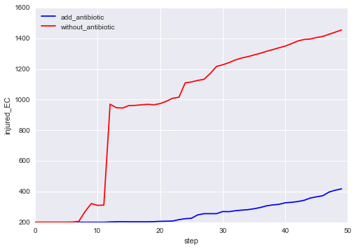

```python
plt.plot(xrange(nsteps),m1.history_injured_EC, 'b-', label = 'add_antibiotic')
plt.plot(xrange(nsteps), m2.history_injured_EC, 'r-', label = 'without_antibiotic')
plt.legend(loc='upper left')
plt.xlabel('step')
plt.ylabel('injured_EC')
plt.show()
```

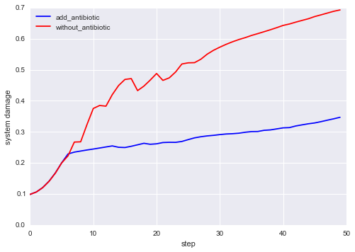

```python
plt.plot(xrange(nsteps),m1.history_system_damage, 'b-', label = 'add_antibiotic')
plt.plot(xrange(nsteps), m2.history_system_damage, 'r-', label = 'without_antibiotic')
plt.legend(loc='upper left')
plt.xlabel('step')
plt.ylabel('system damage')
plt.show()
```

From above two figures comparing the injured EC number and total system damage along time, it is clear that addition of antibiotics greatly improved the system. We would use the experiment of antibiotic as control for further comparison.

As stated in Code-Parameter sweeping part, the interferences are tested and their performance is measured by the mean of living time(steps before system damage reaches 80%), number of injured EC at 100 steps and 200 steps, total system damage at 100 steps and 200 steps. A wilcoxon test was used to compare all the 30 simulations in the given condition with control.

The results of using different antibodiess are recorded in Table 4 and different and receptor modulators Table 5.

Table 4. Performance of different antibodies.

| Interference | Living time | p_value | injured EC | p_value | injured EC2 | p_value | system_damage | p_value | system_damage2 | p_value |
| --- | --- | --- | --- | --- | --- | --- | --- | --- | --- | --- |
| none | 68 | 1.71E-06 | 2163 | 1.73E-06 | 2486 | 1.73E-06 | 91.38% | 1.73E-06 | 99.65% | 1.73E-06 |
| antibiotic = 0.1 | 134 | - | 1199 | - | 2380 | - | 62.36% | - | 96.89% | - |
| endotoxin_antibody = 0.5 | 130 | 0.47 | 1230 | 0.9 | 2346 | 0.01 | 63.35% | 0.77 | 96.12% | 0.03 |
| PAF_antibody = 0.5 | 112 | 5.30E-06 | 1535 | 1.02E-05 | 2475 | 1.92E-06 | 71.91% | 1.64E-05 | 99.38% | 1.92E-06 |
| IL_8_antibody = 0.5 | 131 | 0.98 | 1259 | 0.55 | 2369 | 0.26 | 63.93% | 0.78 | 96.65% | 0.35 |
| TNF_antibody = 0.5 | 138 | 0.14 | 1121 | 0.43 | 2365 | 0.17 | 59.97% | 0.26 | 96.48% | 0.17 |
| IL_1_antibody = 0.5 | 134 | 0.62 | 1203 | 0.99 | 2374 | 0.83 | 62.25% | 0.83 | 96.76% | 0.81 |
| IL_1ra_antibody = 0.5 | 131 | 0.52 | 1243 | 0.5 | 2385 | 0.76 | 63.63% | 0.5 | 97.03% | 0.72 |
| GCSF_antibody = 0.5 | 131 | 0.31 | 1237 | 0.98 | 2385 | 0.42 | 63.48% | 0.83 | 97.06% | 0.35 |
| IL_10_antibody = 0.5 | 133 | 0.74 | 1226 | 0.21 | 2365 | 0.2 | 62.81% | 0.6 | 96.44% | 0.21 |
| IL_12_antibody = 0.5 | 130 | 0.24 | 1254 | 0.13 | 2386 | 0.67 | 63.90% | 0.17 | 97.08% | 0.54 |
| INF_g_antibody = 0.5 | 133 | 0.27 | 1202 | 0.74 | 2382 | 0.74 | 62.47% | 0.59 | 96.94% | 0.8 |
| IL_4_antibody = 0.5 | 136 | 0.73 | 1129 | 0.18 | 2371 | 0.64 | 60.29% | 0.44 | 96.67% | 0.81 |
| endotoxin_antibody = 0.1 | 133 | 0.56 | 1187 | 0.15 | 2337 | 0.0026 | 62.03% | 0.086 | 95.93% | 0.01 |
| PAF_antibody = 0.1 | 109 | 6.60E-06 | 1582 | 1.49E-05 | 2484 | 2.12E-06 | 73.27% | 2.16E-05 | 99.60% | 2.12E-06 |
| IL_8_antibody = 0.1 | 129 | 0.12 | 1291 | 0.09 | 2376 | 0.95 | 65.20% | 0.037 | 96.75% | 0.75 |
| TNF_antibody = 0.1 | 131 | 0.39 | 1232 | 0.74 | 2383 | 0.61 | 63.32% | 0.5 | 97.02% | 0.56 |
| IL_1_antibody = 0.1 | 134 | 0.85 | 1202 | 0.52 | 2371 | 0.45 | 62.16% | 0.83 | 96.62% | 0.45 |
| IL_1ra_antibody = 0.1 | 136 | 0.76 | 1148 | 0.21 | 2367 | 0.21 | 60.75% | 0.24 | 96.58% | 0.25 |
| GCSF_antibody = 0.1 | 134 | 0.67 | 1203 | 0.13 | 2371 | 0.39 | 62.17% | 0.18 | 96.62% | 0.43 |
| IL_10_antibody = 0.1 | 132 | 0.92 | 1241 | 0.75 | 2372 | 0.61 | 63.38% | 0.99 | 96.70% | 0.63 |
| IL_12_antibody = 0.1 | 130 | 0.36 | 1265 | 0.23 | 2377 | 0.82 | 64.02% | 0.35 | 96.77% | 0.73 |
| INF_g_antibody = 0.1 | 133 | 0.82 | 1232 | 0.54 | 2367 | 0.17 | 63.04% | 0.89 | 96.53% | 0.25 |
| IL_4_antibody = 0.1 | 131 | 0.56 | 1255 | 0.48 | 2384 | 0.75 | 63.85% | 0.59 | 97% | 0.78 |

Table 5. Performance of different receptor modulators.

| Interference | Living time | p_value | injured EC | p_value | injured EC2 | p_value | system_damage | p_value | system_damage2 | p_value |
| --- | --- | --- | --- | --- | --- | --- | --- | --- | --- | --- |
| antibiotic = 0.1 | 134 | - | 1199 | - | 2380 | - | 62.36% | - | 96.89% | - |
| endotoxin_receptor = 0.5 | 133 | 0.76 | 1225 | 0.61 | 2381 | 0.84 | 62.80% | 0.94 | 96.92% | 0.75 |
| PAF_receptor = 0.5 | 133 | 0.97 | 1193 | 0.15 | 2378 | 84.00% | 62.20% | 0.32 | 96.83% | 0.88 |
| IL_8_receptor = 0.5 | 131 | 0.42 | 1248 | 0.47 | 2385 | 0.63 | 63.65% | 0.6 | 97.06% | 0.6 |
| TNF_receptor = 0.5 | 135 | 0.75 | 1185 | 0.99 | 2371 | 0.17 | 61.76% | 0.86 | 96.65% | 0.24 |
| IL_1_receptor = 0.5 | 136 | 0.64 | 1155 | 0.81 | 2371 | 0.5 | 60.97% | 0.7 | 96.65% | 0.49 |
| IL_1ra_receptor = 0.5 | 133 | 0.94 | 1196 | 0.59 | 2379 | 0.97 | 62.28% | 0.57 | 96.89% | 0.86 |
| IL_10_receptor = 0.5 | 135 | 0.95 | 1181 | 0.85 | 2362 | 0.09 | 61.75% | 0.89 | 96.49% | 0.21 |
| IL_12_receptor = 0.5 | 131 | 0.12 | 1244 | 0.25 | 2378 | 0.9 | 63.58% | 0.2 | 96.80% | 0.77 |
| INF_g_receptor = 0.5 | 135 | 0.6 | 1203 | 0.57 | 2364 | 0.1 | 62.17% | 0.98 | 96.42% | 0.08 |
| IL_4_receptor = 0.5 | 133 | 0.91 | 1210 | 0.89 | 2375 | 0.77 | 62.49% | 0.72 | 96.77% | 0.85 |
| endotoxin_receptor = 0.1 | 133 | 0.59 | 1214 | 0.59 | 2381 | 0.84 | 62.60% | 0.61 | 96.95% | 0.7 |
| PAF_receptor = 0.1 | 136 | 0.63 | 1167 | 0.86 | 2368 | 0.27 | 61.20% | 0.6 | 96.53% | 0.3 |
| IL_8_receptor = 0.1 | 131 | 0.66 | 1260 | 0.42 | 2373 | 0.65 | 63.74% | 0.8 | 96.65% | 0.59 |
| TNF_receptor = 0.1 | 132 | 0.56 | 1241 | 0.21 | 2377 | 0.67 | 63.32% | 0.56 | 96.80% | 0.69 |
| IL_1_receptor = 0.1 | 133 | 0.81 | 1224 | 0.69 | 2385 | 0.57 | 62.90% | 0.91 | 97.06% | 0.47 |
| IL_1ra_receptor = 0.1 | 132 | 0.61 | 1234 | 0.28 | 2378 | 0.87 | 63.23% | 0.81 | 96.84% | 0.81 |
| IL_10_receptor = 0.1 | 132 | 0.4 | 1248 | 0.26 | 2381 | 0.7 | 63.57% | 0.41 | 96.87% | 0.81 |
| IL_12_receptor = 0.1 | 135 | 0.94 | 1192 | 0.51 | 2375 | 0.99 | 61.95% | 0.78 | 96.74% | 0.85 |
| INF_g_receptor = 0.1 | 130 | 0.22 | 1264 | 0.31 | 2385 | 0.49 | 64.17% | 0.35 | 97.04% | 0.49 |
| IL_4_receptor = 0.1 | 133 | 0.73 | 1221 | 0.69 | 2377 | 0.71 | 62.77% | 0.78 | 96.86% | 0.98 |
| PAF_receptor = 2 | 133 | 0.7 | 1211 | 0.85 | 2379 | 0.72 | 62.69% | 0.6 | 96.81% | 0.64 |
| IL_8_receptor = 2 | 131 | 0.29 | 1250 | 0.43 | 2383 | 0.5 | 63.73% | 0.53 | 96.91% | 0.64 |
| TNF_receptor = 2 | 135 | 0.53 | 1188 | 0.85 | 2371 | 0.17 | 61.89% | 0.57 | 96.59% | 0.14 |
| IL_1_receptor = 2 | 131 | 0.3 | 1259 | 0.15 | 2381 | 0.95 | 63.96% | 0.28 | 96.90% | 0.83 |
| IL_1ra_receptor = 2 | 134 | 0.85 | 1209 | 0.69 | 2370 | 0.55 | 62.32% | 0.99 | 96.56% | 0.52 |
| IL_10_receptor = 2 | 132 | 0.69 | 1248 | 0.47 | 2378 | 0.97 | 63.57% | 0.73 | 96.81% | 0.96 |
| IL_12_receptor = 2 | 133 | 0.75 | 1214 | 0.7 | 2376 | 0.74 | 62.53% | 0.37 | 96.75% | 0.66 |
| INF_g_receptor = 2 | 133 | 0.91 | 1247 | 0.4 | 2362 | 0.23 | 63.31% | 0.91 | 96.35% | 0.17 |
| IL_4_receptor = 2 | 131 | 0.46 | 1247 | 0.5 | 2381 | 0.79 | 63.67% | 0.56 | 96.92% | 0.73 |

From the results, it is quite surprising that almost none of the measures taken significantly affects the system, except that PAF_antibody aggravate the situation. In addtion, using endotoxin_antibody with the potency of 0.5 slightly improved the situation at the end of every simulation. These findings suggested that under current settings and initial conditions, there was no single measure(both antibodies and receptor modulators included) can effectively improve the situation compared to treating with antibiotics alone. In further research, similar trials can be dealt with different initial conditions to see if the results remain so. If it is true, then it may suggest that none of the single interference are effective, and the influence of combinational interference need to be explored.

In this ABM, we created a model to simulate the inate immune response process, and tried different interferences to see which one can help prolong living time and reduce total damage. To our surprise, none of the single interferences fulfilled the requirement, which needs further validation but might suggest single interferences are not powerful enough to acchieve the goal and perhaps combinational measures are needed.

### Reference

[1] An G. In silico experiments of existing and hypothetical cytokine-directed clinical trials using agent-based modeling [J]. *Critical Care Medicine*, 2004, 32(10): 2050-2060.

[2] Castellheim A, Brekke O L, Espevik T, et al. Innate immune responses to danger signals in systemic inflammatory response syndrome and sepsis [J]. *Scandinavian Journal of Immunology*, 2009, 69(6): 479-491.

### Acknowledgement

Thank Michael Bommarito and Sarah Cherng, the instructors of the course CSCS530, for their instructions on agent-based modeling, python programming and statistical tests.